# deepSSF Model Training

### Print head of dataframe to choose scalar columns

```python
raw_df
```

|  | name | n_sat | id | x1_ | x2_ | y1_ | y2_ | sl_ | direction_p | ta_ | ... | veg_mudflat | veg_dry_rainforest | veg_eucalypt_open_forest | veg_eucalypt_woodland | veg_floodplain_sedgeland | veg_mangrove | veg_melaleuca_closed_forest | veg_melaleuca_open_forest | veg_melaleuca_woodland | veg_water |
| --- | --- | --- | --- | --- | --- | --- | --- | --- | --- | --- | --- | --- | --- | --- | --- | --- | --- | --- | --- | --- | --- |
| 0 | Betty | 8 | 152638 | -147079.566606 | -146943.383423 | -1.423197e+06 | -1.423458e+06 | 294.751498 | -1.090517 | -0.328911 | ... | 0 | 1 | 0 | 0 | 0 | 0 | 0 | 0 | 0 | 0 |
| 1 | Betty | 5 | 152638 | -146943.383423 | -146926.463908 | -1.423458e+06 | -1.423483e+06 | 29.750385 | -0.965853 | 0.124664 | ... | 0 | 1 | 0 | 0 | 0 | 0 | 0 | 0 | 0 | 0 |
| 2 | Betty | 5 | 152638 | -146926.463908 | -146925.833493 | -1.423483e+06 | -1.423447e+06 | 36.144168 | 1.553354 | 2.519206 | ... | 0 | 1 | 0 | 0 | 0 | 0 | 0 | 0 | 0 | 0 |
| 3 | Betty | 7 | 152638 | -146925.833493 | -146904.536146 | -1.423447e+06 | -1.423442e+06 | 21.866208 | 0.228601 | -1.324753 | ... | 0 | 1 | 0 | 0 | 0 | 0 | 0 | 0 | 0 | 0 |
| 4 | Betty | 7 | 152638 | -146904.536146 | -146941.346298 | -1.423442e+06 | -1.423462e+06 | 41.990170 | -2.639625 | -2.868225 | ... | 0 | 1 | 0 | 0 | 0 | 0 | 0 | 0 | 0 | 0 |
| ... | ... | ... | ... | ... | ... | ... | ... | ... | ... | ... | ... | ... | ... | ... | ... | ... | ... | ... | ... | ... | ... |
| 254392 | Unknown1 | 8 | 159083 | -166739.843538 | -166741.194148 | -1.437664e+06 | -1.437663e+06 | 2.083454 | 2.276087 | 1.803455 | ... | 0 | 0 | 0 | 0 | 1 | 0 | 0 | 0 | 0 | 0 |
| 254393 | Unknown1 | 8 | 159083 | -166741.194148 | -166733.811255 | -1.437663e+06 | -1.437671e+06 | 11.361221 | -0.863432 | -3.139519 | ... | 0 | 0 | 0 | 0 | 1 | 0 | 0 | 0 | 0 | 0 |
| 254394 | Unknown1 | 5 | 159083 | -166733.811255 | -166737.599585 | -1.437671e+06 | -1.437669e+06 | 4.386742 | 2.613136 | -2.806617 | ... | 0 | 0 | 0 | 0 | 1 | 0 | 0 | 0 | 0 | 0 |
| 254395 | Unknown1 | 5 | 159083 | -166737.599585 | -166636.330496 | -1.437669e+06 | -1.437760e+06 | 136.029945 | -0.731068 | 2.938981 | ... | 0 | 0 | 0 | 0 | 1 | 0 | 0 | 0 | 0 | 0 |
| 254396 | Unknown1 | 6 | 159083 | -166636.330496 | -166667.893627 | -1.437760e+06 | -1.437739e+06 | 37.753866 | 2.560792 | -2.991325 | ... | 0 | 0 | 0 | 0 | 1 | 0 | 0 | 0 | 0 | 0 |

254397 rows × 77 columns

## `SCALAR_COLS`

These are non-spatial inputs. For processing with convolutional layers, they are converted into spatial windows (rasters/arrays), and stacked with the truly spatial covariates.

The model receives a fixed-size spatial window centred on each step’s start location. To let the network express time-varying habitat preferences (e.g. different nocturnal vs diurnal use), scalar covariates are tiled into additional channels of the same H × W size, so every pixel “knows” the current time context when habitat suitability is estimated.

- `hour_t1_sin1` / `hour_t1_cos1`
  - Sine and cosine of (2π × hour / 24), encoding time-of-day as a *circular* variable. The circular encoding means 23:00 and 01:00 are treated as adjacent — a plain hour value would have an artificial discontinuity at midnight.
- `yday_t1_sin1` / `yday_t1_cos1`
  - Same circular encoding for day-of-year (1–365), capturing seasonal variation in habitat use (e.g. dry-season vs wet-season movements).
- `dt_hour`
  - Elapsed time between consecutive fixes (hours). Because GPS collars do not always fix at a perfectly regular rate, including dt_hour lets the movement kernel rescale expected displacement proportionally to the actual time interval rather than assuming a fixed fix rate. Note: dt_hour must be supplied at *simulation* time as well, so that `simulate_trajectory()` produces inputs consistent with training.
- Weather covariates from the `onpli_` weather station, carried over from the CSV for the start of each step:
  - `rain_30min_mm`, `air_temp_c`, `wet_bulb_temp_c`, `dew_point_temp_c`, `rel_humidity_pct`, `wind_speed_kmh`
    - Standardised to z-scores (the `*_scaled` columns) before going into the model, with rain log-transformed, log(1 + x), first. The mean and SD are kept so model inputs and effects can be converted back to natural units.
  - `wind_dir_deg`
    - Encoded as a sine/cosine pair (`onpli_wind_dir_sin1` / `onpli_wind_dir_cos1`) for the same wraparound reason as hour of day, with calm steps set to (0, 0).

```python
# Time covariates derived by prepare_movement_df().  Not scaled: the sin/cos pairs
# are already in [-1, 1], and simulate_trajectory() fills dt_hour with the raw
# time_between_steps (hours), so the model has to be trained on raw hours too.
TIME_COLS = ["hour_t1_sin1",
             "hour_t1_cos1",
             "yday_t1_sin1",
             "yday_t1_cos1",
             "dt_hour"]

# Weather covariates carried over from the CSV in natural units, and standardised
# to z-scores further down (the "_scaled" columns)
WEATHER_COLS = ["onpli_rain_30min_mm",
                "onpli_air_temp_c",
                "onpli_wet_bulb_temp_c",
                "onpli_dew_point_temp_c",
                "onpli_rel_humidity_pct",
                "onpli_wind_speed_kmh"
                ]

# Wind direction (degrees) is carried over, then encoded as a sin/cos pair further
# down rather than scaled
WIND_DIR_COL = "onpli_wind_dir_deg"

# The model inputs, in the order the model sees them
SCALAR_COLS = (
    TIME_COLS
    + [f"{col}_scaled" for col in WEATHER_COLS]
    + ["onpli_wind_dir_sin1", "onpli_wind_dir_cos1"]
)
print(f"{len(SCALAR_COLS)} scalar inputs: {SCALAR_COLS}")
```

```
13 scalar inputs: ['hour_t1_sin1', 'hour_t1_cos1', 'yday_t1_sin1', 'yday_t1_cos1', 'dt_hour', 'onpli_rain_30min_mm_scaled', 'onpli_air_temp_c_scaled', 'onpli_wet_bulb_temp_c_scaled', 'onpli_dew_point_temp_c_scaled', 'onpli_rel_humidity_pct_scaled', 'onpli_wind_speed_kmh_scaled', 'onpli_wind_dir_sin1…
```

## `prepare_movement_df()`

Converts a fixes dataframe (one row per GPS location) into a *step* dataframe (one row per movement between consecutive fixes).

- For each step it computes:
  - `dx`, `dy` — displacement in projected CRS units (metres)
  - `bearing` — direction of travel (radians; 0 = north, clockwise positive)
  - `bearing_tm1` — bearing of the *previous* step, used as a model input so the network can capture directional persistence by estimating a turning angle
  - `dt_hour` — time elapsed between consecutive fixes (hours)
  - `hour_t1`, `yday_t1` — decimal hour-of-day and day-of-year at the step start location
  - `*_sin1` / `*_cos1` — sine/cosine encodings of hour and yday (see SCALAR_COLS below)

The “1” on column names (x1_, y1_, t1_, etc.) flags them as “start of step” variables; and the “2” in x2_, y2_, t2_ are the corresponding “end of step” values, following the convention of the `amt` package (Signer et al. 2019). The last fix for each individual is dropped because no forward step can be formed.

```python
# The CSV is already in amt step format, but prepare_movement_df() expects one row
# per *fix* and rebuilds the steps itself (it also derives bearing, dt_hour and the
# cyclic time encodings the model needs).  Point it at the step-start columns and
# let it re-form the steps from consecutive fixes.
step_df = deepssf.prepare_movement_df(
    raw_df,
    id_col="name",
    time_col="t1_",
    x_col="x1_",
    y_col="y1_",
    # derives the time cols; carries the weather and wind direction cols over
    scalar_cols=TIME_COLS + WEATHER_COLS + [WIND_DIR_COL],
)
n_dropped = len(raw_df) - len(step_df)
print(f"Movement steps : {len(step_df):,}  ({n_dropped} dropped — last per individual)")
step_df.head()
```

```
Movement steps : 254,378  (19 dropped — last per individual)
```

|  | id | t1_ | x1_ | y1_ | t2_ | x2_ | y2_ | dx | dy | sl_ | ... | hour_t1_cos1 | yday_t1_sin1 | yday_t1_cos1 | onpli_rain_30min_mm | onpli_air_temp_c | onpli_wet_bulb_temp_c | onpli_dew_point_temp_c | onpli_rel_humidity_pct | onpli_wind_speed_kmh | onpli_wind_dir_deg |
| --- | --- | --- | --- | --- | --- | --- | --- | --- | --- | --- | --- | --- | --- | --- | --- | --- | --- | --- | --- | --- | --- |
| 0 | Betty | 2025-10-10 09:00:15+00:00 | -147079.566606 | -1.423197e+06 | 2025-10-10 09:30:25+00:00 | -146943.383423 | -1.423458e+06 | 136.183183 | -261.405024 | 294.751498 | ... | -0.707107 | -0.987873 | 0.155266 | 0.0 | 28.8 | 25.9 | 24.6 | 78.0 | 3.6 | 90.0 |
| 1 | Betty | 2025-10-10 09:30:25+00:00 | -146943.383423 | -1.423458e+06 | 2025-10-10 10:00:27+00:00 | -146926.463908 | -1.423483e+06 | 16.919515 | -24.470705 | 29.750385 | ... | -0.793353 | -0.987873 | 0.155266 | 0.0 | 29.3 | 25.9 | 24.4 | 75.0 | 5.4 | 70.0 |
| 2 | Betty | 2025-10-10 10:00:27+00:00 | -146926.463908 | -1.423483e+06 | 2025-10-10 10:31:02+00:00 | -146925.833493 | -1.423447e+06 | 0.630415 | 36.138670 | 36.144168 | ... | -0.866025 | -0.987873 | 0.155266 | 0.2 | 30.6 | 25.7 | 23.5 | 66.0 | 9.4 | 40.0 |
| 3 | Betty | 2025-10-10 10:31:02+00:00 | -146925.833493 | -1.423447e+06 | 2025-10-10 11:00:14+00:00 | -146904.536146 | -1.423442e+06 | 21.297347 | 4.955208 | 21.866208 | ... | -0.925541 | -0.987873 | 0.155266 | 0.0 | 32.1 | 26.2 | 23.6 | 61.0 | 14.8 | 80.0 |
| 4 | Betty | 2025-10-10 11:00:14+00:00 | -146904.536146 | -1.423442e+06 | 2025-10-10 11:30:27+00:00 | -146941.346298 | -1.423462e+06 | -36.810152 | -20.203639 | 41.990170 | ... | -0.965926 | -0.987873 | 0.155266 | 0.0 | 32.1 | 26.0 | 23.3 | 60.0 | 13.0 | 80.0 |

5 rows × 27 columns

### Check and drop NAs

```python
# Columns that must be complete for a step to be used
NA_CHECK_COLS = TIME_COLS + WEATHER_COLS + [WIND_DIR_COL]

# --- Check: missing values per column ---
na_mask = step_df[NA_CHECK_COLS].isna()
print("Missing values per column:")
print(na_mask.sum().to_string())

# --- Drop: every step with a missing value in any of these columns ---
drop_rows = na_mask.any(axis=1)
if drop_rows.any():
    # Record which column(s) caused each dropped step (kept for inspection)
    dropped_steps = step_df.loc[drop_rows, ["id", "t1_"]].copy()
    dropped_steps["na_cols"] = na_mask[drop_rows].apply(
        lambda row: ", ".join(row.index[row]), axis=1
    )
    print(f"\nDropping {drop_rows.sum():,} of {len(step_df):,} steps "
          f"({drop_rows.mean():.2%}).  Column(s) with NAs that caused the drop:")
    print(dropped_steps["na_cols"].value_counts().to_string())
    step_df = step_df.loc[~drop_rows].reset_index(drop=True)
else:
    print("\nNo steps with missing values.")

print(f"\nSteps remaining: {len(step_df):,}")
```

```
Missing values per column:
hour_t1_sin1                 0
hour_t1_cos1                 0
yday_t1_sin1                 0
yday_t1_cos1                 0
dt_hour                      0
onpli_rain_30min_mm       5583
onpli_air_temp_c          1651
onpli_wet_bulb_temp_c     1651
onpli_dew_point_temp_c    1651
onpli_rel_humidity_pct    1651
onpli_wind_speed_kmh      1460
onpli_wind_dir_deg        1479

Dropping 7,104 of 254,378 steps (2.79%).  Column(s) with NAs that caused the drop:
na_cols
onpli_rain_30min_mm                                                                                                                                       4234
onpli_air_temp_c, onpli_wet_bulb_temp_c, onpli_dew_point_temp_c, onpli_rel_humidity_pct                                                                    990
onpli_rain_30min_mm, onpli_wind_speed_kmh, onpli_wind_dir_deg                                                                                              699
onpli_wind_speed_kmh, onpli_wind_dir_deg                                                                                                                   501
onpli_rain_30min_mm, onpli_air_temp_c, onpli_wet_bulb_temp_c, onpli_dew_point_temp_c, onpli_rel_humidity_pct                                               401
onpli_rain_30min_mm, onpli_air_temp_c, onpli_wet_bulb_temp_c, onpli_dew_point_temp_c, onpli_rel_humidity_pct, onpli_wind_speed_kmh, onpli_wind_dir_deg     249
onpli_wind_dir_deg                                                                                                                                          19
onpli_air_temp_c, onpli_wet_bulb_temp_c, onpli_dew_point_temp_c, onpli_rel_humidity_pct, onpli_wind_speed_kmh, onpli_wind_dir_deg                           11

Steps remaining: 247,274
```

### Encode wind direction as a sin/cos pair

Wind direction follows the BoM convention: the compass bearing the wind blows *from*, in 10° steps clockwise from north (90 = from the east). North is recorded as 360, and 0 is reserved for **calm** (no wind, so no direction).

Taking the sine and cosine removes the wraparound, so 350° and 10° sit next to each other and 0° and 360° both mean north: - `onpli_wind_dir_sin1` — east–west component (+1 = from the east, −1 = from the west) - `onpli_wind_dir_cos1` — north–south component (+1 = from the north, −1 = from the south)

Calm steps are set to (0, 0). A plain sin/cos of 0° gives (0, 1), which the model would read as a northerly. `wind_dir_from_sin_cos()` converts back to 0–360° (0 = north), returning NaN for calm.

```python
def wind_dir_to_sin_cos(deg):
    """Compass degrees (0 = north, clockwise) -> (sin, cos)."""
    rad = np.radians(np.asarray(deg, dtype=float))
    return np.sin(rad), np.cos(rad)


def wind_dir_from_sin_cos(sin1, cos1):
    """(sin, cos) -> compass degrees in [0, 360), 0 = north.  NaN for calm (0, 0)."""
    sin1 = np.asarray(sin1, dtype=float)
    cos1 = np.asarray(cos1, dtype=float)
    # Round before wrapping so north comes back as 0 rather than 359.99999...
    deg = np.round(np.degrees(np.arctan2(sin1, cos1)), 6) % 360
    return np.where(np.hypot(sin1, cos1) < 1e-6, np.nan, deg)


calm = (step_df[WIND_DIR_COL] == 0).to_numpy()   # BoM code for calm
wind_sin, wind_cos = wind_dir_to_sin_cos(step_df[WIND_DIR_COL])
step_df["onpli_wind_dir_sin1"] = np.where(calm, 0.0, wind_sin)
step_df["onpli_wind_dir_cos1"] = np.where(calm, 0.0, wind_cos)

# --- Checks ---
# 1. Calm (direction 0) should coincide with zero wind speed
print(f"Calm steps (direction 0): {calm.sum():,}, of which wind speed is 0: "
      f"{(step_df.loc[calm, 'onpli_wind_speed_kmh'] == 0).sum():,}\n")

# 2. Compass points encode and decode as expected, including across 360/0
check = pd.DataFrame({"deg": [360, 10, 90, 180, 270, 350]})
check["sin1"], check["cos1"] = wind_dir_to_sin_cos(check["deg"])
check["recovered_deg"] = wind_dir_from_sin_cos(check["sin1"], check["cos1"])
print(check.round(3).to_string(index=False))

# 3. Round trip on the data recovers every non-calm direction (360 comes back as 0)
#    and returns NaN for every calm step
recovered = wind_dir_from_sin_cos(step_df["onpli_wind_dir_sin1"], step_df["onpli_wind_dir_cos1"])
diff = (recovered[~calm] - step_df.loc[~calm, WIND_DIR_COL].to_numpy() + 180) % 360 - 180
print(f"\nMax round-trip error (non-calm): {np.abs(diff).max():.1e} deg;  "
      f"calm steps recovered as NaN: {np.isnan(recovered[calm]).all()}")
```

```
Calm steps (direction 0): 42,322, of which wind speed is 0: 42,322

 deg   sin1   cos1  recovered_deg
 360 -0.000  1.000            0.0
  10  0.174  0.985           10.0
  90  1.000  0.000           90.0
 180  0.000 -1.000          180.0
 270 -1.000 -0.000          270.0
 350 -0.174  0.985          350.0

Max round-trip error (non-calm): 0.0e+00 deg;  calm steps recovered as NaN: True
```

### Standardise the weather covariates

Converts each weather covariate to a z-score, (x − mean) / SD, so it sits on a similar scale to the sin/cos time encodings. The natural-unit columns stay in `step_df`, and the scaled copies get a `_scaled` suffix.

Rain is mostly 0 with a long tail of heavy falls, so on its own a z-score would put the biggest downpours dozens of SDs out. Rain is therefore log-transformed first, log(1 + x), which keeps 0 at 0 and pulls in the tail, and the z-score is taken on the logged values.

The transform, mean and SD for each column are stored in `SCALING` and saved to `scalar_scaling.csv` in `OUTPUT_DIR`: - `unscale_covariate(values, col)` converts back to natural units: natural = scaled × SD + mean, followed by exp(x) − 1 for log1p columns. - `scale_covariate(values, col)` scales new weather values, e.g. for prediction or simulation, with these same coefficients. - To reload them later: `pd.read_csv(OUTPUT_DIR / "scalar_scaling.csv", index_col="column")`. The two functions only read `SCALING`, so they work on the reloaded table.

```python
# Columns log-transformed, log(1 + x), before the z-score.  Add any other heavily
# right-skewed, non-negative covariates here.
LOG1P_COLS = ["onpli_rain_30min_mm"]

# Transform, mean and SD for each weather covariate (after dropping NAs).  The
# mean/SD are of the transformed values, i.e. of log(1 + rain) for rain.
SCALING = pd.DataFrame(
    {"transform": ["log1p" if col in LOG1P_COLS else "none" for col in WEATHER_COLS]},
    index=pd.Index(WEATHER_COLS, name="column"),
)
for col in WEATHER_COLS:
    values = step_df[col].to_numpy(dtype=float)
    if SCALING.at[col, "transform"] == "log1p":
        values = np.log1p(values)
    SCALING.at[col, "mean"] = values.mean()
    SCALING.at[col, "sd"] = values.std(ddof=1)


def scale_covariate(values, col):
    """Natural units -> model scale for `col`: log1p if listed, then z-score."""
    values = np.asarray(values, dtype=float)
    if SCALING.at[col, "transform"] == "log1p":
        values = np.log1p(values)
    return (values - SCALING.at[col, "mean"]) / SCALING.at[col, "sd"]


def unscale_covariate(values, col):
    """Model scale -> natural units for `col`: undo the z-score, then expm1 if logged."""
    values = np.asarray(values, dtype=float) * SCALING.at[col, "sd"] + SCALING.at[col, "mean"]
    if SCALING.at[col, "transform"] == "log1p":
        values = np.expm1(values)
    return values


for col in WEATHER_COLS:
    step_df[f"{col}_scaled"] = scale_covariate(step_df[col], col)

SCALING.to_csv(OUTPUT_DIR / "scalar_scaling.csv")
print("Scaling coefficients:")
print(SCALING.round(3).to_string())

# Check: the scaled columns have mean 0 and SD 1, and unscaling recovers the originals
scaled_cols = [f"{col}_scaled" for col in WEATHER_COLS]
print("\nScaled columns:")
print(step_df[scaled_cols].agg(["mean", "std", "min", "max"]).T.round(3).to_string())
assert all(np.allclose(unscale_covariate(step_df[f"{col}_scaled"], col), step_df[col])
           for col in WEATHER_COLS)
print(f"\nUnscaling recovers the originals.  Saved to {OUTPUT_DIR / 'scalar_scaling.csv'}")
```

```
Scaling coefficients:
                       transform    mean      sd
column
onpli_rain_30min_mm        log1p   0.034   0.203
onpli_air_temp_c            none  27.811   3.945
onpli_wet_bulb_temp_c       none  23.792   2.700
onpli_dew_point_temp_c      none  21.593   4.172
onpli_rel_humidity_pct      none  72.692  20.675
onpli_wind_speed_kmh        none   7.198   5.803

Scaled columns:
                               mean  std    min     max
onpli_rain_30min_mm_scaled     -0.0  1.0 -0.165  17.344
onpli_air_temp_c_scaled         0.0  1.0 -4.160   2.912
onpli_wet_bulb_temp_c_scaled    0.0  1.0 -4.738   2.151
onpli_dew_point_temp_c_scaled   0.0  1.0 -4.361   1.608
onpli_rel_humidity_pct_scaled  -0.0  1.0 -2.887   1.224
onpli_wind_speed_kmh_scaled     0.0  1.0 -1.240   5.153

Unscaling recovers the originals.  Saved to outputs/landcover/2026-11-18_2/scalar_scaling.csv
```

## `PIXEL_SIZE`

Raster resolution in CRS units (metres here). Read straight off `raster_transform` rather than typed in: the transform is the authority on the grid the model is trained against, and a hand-entered value that disagrees with it silently mis-scales the movement kernel — which is parameterised in metres — against a grid measured in pixels.

```python
# transform.a is the cell width, transform.e the (negative) cell height
PIXEL_SIZE = abs(raster_transform.a)

if not math.isclose(abs(raster_transform.a), abs(raster_transform.e)):
    raise ValueError(
        f"Non-square pixels ({abs(raster_transform.a)} x {abs(raster_transform.e)}); "
        "the model assumes square cells."
    )

print(f"Pixel size: {PIXEL_SIZE} m")
```

```
Pixel size: 20.0 m
```

## `WINDOW_SIZE`

The size of the local availability window in cells/pixels.

The maximum step length that the model will allow is the distance between the centre cell and the nearest edge (in reality some steps may be longer if they are in the corners).

```python
WINDOW_SIZE = 75

print(f"Pixel size: {PIXEL_SIZE} m  →  window {WINDOW_SIZE} px = "
      f"{WINDOW_SIZE * PIXEL_SIZE:,.0f} m across")

print(f"Maximum possible step: {((WINDOW_SIZE - 1) / 2) * PIXEL_SIZE:,.0f} m")
```

```
Pixel size: 20.0 m  →  window 75 px = 1,500 m across
Maximum possible step: 740 m
```

## `BATCH_SIZE`

Number of training samples (movement steps) per training mini-batch

```python
BATCH_SIZE  = 128
```

## `N_CONV_LAYERS_MOVE`

How many convolutional layers in the movement subnetwork of the model?

Each of the convolution layers has a max pooling layer, so more layers will result in greater dimension reduction that will feed into the fully-connected layer that outputs the movement parameters.

```python
N_CONV_LAYERS_MOVE = 4
```

## `N_CONV_LAYERS_HAB`

How many convolutional layers in the habitat selection subnetwork of the model?

These convolution layers do not have max pooling layers, so there is no dimension reduction. More layers will increase the depth of the model and allow for more abstracted features to be identified, but will slow model training/prediction.

This count includes the final convolution layer, which is the one that collapses the feature maps down to the single-channel habitat selection surface, so the minimum is 1.

```python
N_CONV_LAYERS_HAB = 6
```

## `OUTPUT_CHANNELS`

Number of convolutional filters (and therefore feature maps) for **each** convolution layer. More convolutional filters can provide more flexible functions, but will increase the number of parameters and slow down training times.

```python
OUTPUT_CHANNELS = 8
```

## `DENSE_DIM_HIDDEN`

How many neurons are in each layer of the multilayer perceptron for the movement subnetwork, after the convolution layers?

```python
DENSE_DIM_HIDDEN = 128
```

### Pre-calculate the flattened CNN output size

This value will be the input to the fully-connected layers in the movement subnetwork, and is calculated here so that ModelParams can be set without hard-coding it.

`flattened_conv_dim()` reproduces exactly what the layers inside `ConvJointModel` do to the spatial dimensions: * conv (padding=1) keeps the spatial dimension unchanged at each layer * maxpool k=2, s=2 halves the spatial dimension (floor division) at each layer

Because every movement conv layer is paired with a max pooling layer, this size depends on `N_CONV_LAYERS_MOVE` — so it has to be recalculated whenever that (or `WINDOW_SIZE`, or `OUTPUT_CHANNELS`) changes. It raises an error if the window is pooled away to nothing, which means too many layers for the window size.

```python
DENSE_DIM = deepssf.flattened_conv_dim(
    image_dim=WINDOW_SIZE,
    n_conv_layers_move=N_CONV_LAYERS_MOVE,
    output_channels=OUTPUT_CHANNELS,
)
print(f"After {N_CONV_LAYERS_MOVE}x conv+maxpool: dense_dim_in_all={DENSE_DIM}")
```

```
After 4x conv+maxpool: dense_dim_in_all=128
```

## `filter_steps_by_window()`

Removes steps whose straight-line displacement exceeds half the spatial window (WINDOW_SIZE × PIXEL_SIZE / 2 metres). Such steps would place the true next location outside the predicted probability map, causing an index error in the loss function.

```python
original_data_size = len(step_df)

step_df = deepssf.filter_steps_by_window(
    step_df, window_size=WINDOW_SIZE, pixel_size=PIXEL_SIZE
)

print(f"Initial number of steps: {original_data_size:,}")
print(f"Steps after window filter: {len(step_df):,}")
print(f"Data reduction: {original_data_size - len(step_df):,} ({(original_data_size - len(step_df)) / original_data_size * 100:.1f}%)")
```

```
Initial number of steps: 247,274
Steps after window filter: 245,672
Data reduction: 1,602 (0.6%)
```

## `make_dataloaders()`

Splits step_df into train / val / test subsets (here 80 / 10 / 10 %) and returns a PyTorch DataLoader for each.

- Each DataLoader yields tuples of:
  - `x1` — spatial window tensor (batch × n_spatial_channels × H × W)
    - One channel per raster *band* in LAYER_PATHS, cropped around each step’s start pixel.
  - `x2` — scalar covariate tensor (batch × len(SCALAR_COLS))
    - Raw scalar values; broadcast into spatial maps *inside* the model.
  - `x3` — previous bearing tensor (batch × 1)
    - Conditions the movement kernel on the direction of the prior step.
  - `(px2, py2)` — pixel indices of the *true* next location within the window
    - Used by the loss function to look up the predicted probability at the observed destination.

The layer_paths argument causes the function to re-read the rasters internally, so the DataLoader is independent of the env_layers dict loaded above.

```python
dl_train, dl_val, dl_test = deepssf.make_dataloaders(
    layer_paths=LAYER_PATHS,
    window_size=WINDOW_SIZE,
    batch_size=BATCH_SIZE,
    train_split=0.8,
    val_split=0.1,
    scalar_cols=SCALAR_COLS,
    df=step_df,
)
print(f"Train batches : {len(dl_train)}")
print(f"Val   batches : {len(dl_val)}")
print(f"Test  batches : {len(dl_test)}")
```

```
Layer 'dem': min=-2.8075695037841797, max=70.5344009399414 → scaled to [0, 1]
Layer 'slope': min=0.0, max=10.422045707702637 → scaled to [0, 1]
Layer 'landcover': min=0.0, max=1.0 → scaled to [0, 1]
Train batches : 1536
Val   batches : 192
Test  batches : 192
```

### Inspect one batch to verify tensor shapes match ModelParams expectations

*`next(iter(dl_train))` will call the next batch, which are randomly shuffled, so calling the function again will provide different training samples.*

```python
x1, x2, x3, (px2, py2), _ = next(iter(dl_train))
print(f"Spatial   x1 : {x1.shape}   (batch × channels × H × W)")
print(f"Scalars   x2 : {x2.shape}   (batch × len(SCALAR_COLS))")
print(f"Bearing   x3 : {x3.shape}   (batch × 1)")
print(f"Next-step px2: {px2[:4].tolist()}  py2: {py2[:4].tolist()}")
```

```
Spatial   x1 : torch.Size([128, 12, 75, 75])   (batch × channels × H × W)
Scalars   x2 : torch.Size([128, 13])   (batch × len(SCALAR_COLS))
Bearing   x3 : torch.Size([128, 1])   (batch × 1)
Next-step px2: [38, 37, 37, 37]  py2: [37, 37, 37, 37]
```

### Plot the first set of tiles in the batch

```python
# Plot the spatial window "tiles" from the first batch: one row per sample, one
# column per raster band.  The centre pixel is the step's start location and the
# cross marks the true next location that the loss function will look up, so this
# is the quickest way to confirm the crops and targets line up with the rasters.
n_samples = 4  # how many samples from the batch to display
n_channels = 6 # number of spatial channels (bands) in the model input
# n_channels = x1.shape[1] # to show all layers, or set to a smaller number to avoid a huge figure

# Band labels straight from the GeoTIFF metadata, in the channel order the model sees
channel_labels = []
for name, arr in env_layers.items():
    if arr.ndim == 2:
        channel_labels.append(name)
        continue
    with rasterio.open(LAYER_PATHS[name]) as src:
        descs = src.descriptions
    for band in range(arr.shape[0]):
        channel_labels.append(descs[band] if descs and descs[band] else f"{name} b{band + 1}")

n_show = min(n_samples, x1.shape[0])
n_chan = min(n_channels, x1.shape[1])
centre = WINDOW_SIZE // 2

fig, axes = plt.subplots(
    n_show, n_chan, figsize=(3.0 * n_chan, 3.0 * n_show), squeeze=False
)

for row in range(n_show):
    for col in range(n_chan):
        ax = axes[row, col]
        tile = x1[row, col].numpy()
        ax.imshow(tile, cmap="viridis", origin="upper")
        # Start location: always the centre cell of the window by construction
        ax.plot(centre, centre, "w+", markersize=9, markeredgewidth=1.5)
        # True next step — px2 is the column index, py2 the row index
        ax.plot(px2[row].item(), py2[row].item(), "rx", markersize=9, markeredgewidth=1.5)
        ax.set_xticks([])
        ax.set_yticks([])
        if row == 0:
            ax.set_title(channel_labels[col], fontsize=10)
        if col == 0:
            ax.set_ylabel(
                f"sample {row}\n→ ({px2[row].item()}, {py2[row].item()})", fontsize=8
            )

fig.suptitle(
    f"First batch: {WINDOW_SIZE}×{WINDOW_SIZE} tiles  "
    "(white + = step start, red × = observed next step)",
    y=1.0,
)
plt.tight_layout()
plt.savefig(str(OUTPUT_DIR / "batch_tiles.png"), dpi=100, bbox_inches="tight")
plt.show()
```

[figure not shown]

## `ModelParams`

A thin dict-like container (it is a wrapper around something else rather than storing data) that groups all architecture hyper-parameters so they can be passed to ConvJointModel and logged together.

This is where the parameters that are passed to the model are set.

```python
params = deepssf.ModelParams({
    "batch_size":                BATCH_SIZE,
    "image_dim":                 WINDOW_SIZE,           # spatial window size (pixels)
    "pixel_size":                PIXEL_SIZE,            # metres per pixel
    "dim_in_nonspatial_to_grid": len(SCALAR_COLS),      # scalar cols tiled into window
    "dense_dim_in_nonspatial":   len(SCALAR_COLS),      # scalar inputs to the dense MLP
    "dense_dim_hidden":          DENSE_DIM_HIDDEN,      # hidden units in the movement MLP
    "dense_dim_in_all":          DENSE_DIM,             # flattened CNN output size
    # One channel per raster band (not per layer) + the tiled scalar covariates
    "input_channels":            N_SPATIAL_CHANNELS + len(SCALAR_COLS),
    "output_channels":           OUTPUT_CHANNELS,       # feature maps per conv layer
    "kernel_size":               3,                     # conv kernel spatial size
    "stride":                    1,                     # conv stride (should be kept at 1)
    "kernel_size_mp":            2,                     # max-pool kernel size
    "stride_mp":                 2,                     # max-pool stride
    "padding":                   1,                     # same-padding preserves spatial dimensions
    "num_movement_params":       12,                    # movement kernel parameters
    "n_conv_layers_hab":         N_CONV_LAYERS_HAB,     # conv layers, habitat branch
    "n_conv_layers_move":        N_CONV_LAYERS_MOVE,    # conv+maxpool layers, movement
    "dropout":                   0.0,
    "device":                    DEVICE,
})
print(f"input_channels: {params.input_channels}  (must match x1 channels + len(SCALAR_COLS))")
```

```
input_channels: 25  (must match x1 channels + len(SCALAR_COLS))
```

## `ConvJointModel`

The deepSSF model! A joint habitat–movement model with two heads: 1. Habitat head — a small CNN applied to the spatial window (env layers + tiled scalars) that outputs a per-pixel log-suitability map. 2. Movement head — a dense MLP (fully-connected layer) that takes the scalar covariates and the previous bearing, and produces parameters for a parametric movement kernel (a mixture of wrapped distributions centred on the current location).

The two log-probability surfaces are summed pixel-wise to give the joint predicted probability map for the animal’s next step.

```python
model = deepssf.ConvJointModel(params).to(DEVICE)
n_params = sum(p.numel() for p in model.parameters())
print(f"Model parameters : {n_params:,}")
```

```
Model parameters : 42,349
```

### Print the model structure

```python
print(model)
```

```
ConvJointModel(
  (scalar_grid_output): Scalar_to_Grid_Block()
  (conv_habitat): Conv2d_block_spatial(
    (conv2d): Sequential(
      (0): Conv2d(25, 8, kernel_size=(3, 3), stride=(1, 1), padding=(1, 1))
      (1): ReLU()
      (2): Conv2d(8, 8, kernel_size=(3, 3), stride=(1, 1), padding=(1, 1))
      (3): ReLU()
      (4): Conv2d(8, 8, kernel_size=(3, 3), stride=(1, 1), padding=(1, 1))
      (5): ReLU()
      (6): Conv2d(8, 8, kernel_size=(3, 3), stride=(1, 1), padding=(1, 1))
      (7): ReLU()
      (8): Conv2d(8, 8, kernel_size=(3, 3), stride=(1, 1), padding=(1, 1))
      (9): ReLU()
      (10): Conv2d(8, 1, kernel_size=(3, 3), stride=(1, 1), padding=(1, 1))
    )
  )
  (conv_movement): Conv2d_block_toFC(
    (conv2d): Sequential(
      (0): Conv2d(25, 8, kernel_size=(3, 3), stride=(1, 1), padding=(1, 1))
      (1): ReLU()
      (2): MaxPool2d(kernel_size=2, stride=2, padding=0, dilation=1, ceil_mode=False)
      (3): Conv2d(8, 8, kernel_size=(3, 3), stride=(1, 1), padding=(1, 1))
      (4): ReLU()
      (5): MaxPool2d(kernel_size=2, stride=2, padding=0, dilation=1, ceil_mode=False)
      (6): Conv2d(8, 8, kernel_size=(3, 3), stride=(1, 1), padding=(1, 1))
      (7): ReLU()
      (8): MaxPool2d(kernel_size=2, stride=2, padding=0, dilation=1, ceil_mode=False)
      (9): Conv2d(8, 8, kernel_size=(3, 3), stride=(1, 1), padding=(1, 1))
      (10): ReLU()
      (11): MaxPool2d(kernel_size=2, stride=2, padding=0, dilation=1, ceil_mode=False)
      (12): Flatten(start_dim=1, end_dim=-1)
    )
  )
  (fcn_movement_all): FCN_block_all_movement(
    (ffn): Sequential(
      (0): Linear(in_features=128, out_features=128, bias=True)
      (1): Dropout(p=0.0, inplace=False)
      (2): ReLU()
      (3): Linear(in_features=128, out_features=128, bias=True)
      (4): Dropout(p=0.0, inplace=False)
      (5): ReLU()
      (6): Linear(in_features=128, out_features=12, bias=True)
    )
  )
  (movement_grid_output): Params_to_Grid_Block_ChV()
)
```

## `negativeLogLikeLoss`

Scores each predicted probability map against the true next-step pixel index; minimising it pushes probability mass toward observed locations.

```python
loss_fn = deepssf.negativeLogLikeLoss(reduction="mean")
```

## `make_optimisers()`

Creates two Adam optimisers with separate learning rates:

- `lr_habitat`
  - controls the CNN (habitat) head
- `lr_movement`
  - controls the movement branch (`conv_movement` + `fcn_movement_all`), kept lower for stability

It also returns a `ReduceLROnPlateau` scheduler for each optimiser that reduces the learning rate by a factor of `scheduler_factor` if that head’s validation loss does not improve for `scheduler_patience` epochs.

Note that each scheduler now watches **its own** component of the validation loss. Previously both watched the combined loss, which is dominated by the movement component — so the movement head’s plateau was what cut the habitat learning rate. With that fixed, the two learning rates no longer have to be separated by two orders of magnitude to stop movement from running away with training; start closer together and tune from there.

```python
optimisers, schedulers = deepssf.make_optimisers(
    model,
    lr_habitat=5e-5,
    lr_movement=1e-5,
    scheduler_patience=3,
    scheduler_factor=0.5
)
```

## `EarlyStopping()`

Defines when the model should stop training.

- `patience`
  - If the loss doesn’t improve for `patience` epochs, terminate training

```python
early_stop = deepssf.EarlyStopping(
    patience=10,
    verbose=True,
    monitor="both",                 # stop only when BOTH heads have plateaued
    path=str(OUTPUT_DIR / "best_model.pt"),
    checkpoint_on="active",         # a habitat-only stage saves on habitat loss
    # Also keep each head's own best epoch, across the whole run
    head_paths={
        "habitat":  str(OUTPUT_DIR / "best_model_habitat.pt"),
        "movement": str(OUTPUT_DIR / "best_model_movement.pt"),
    },
)
```

## `fit()`

Runs the full training loop.

- Inputs:
  - `model`
    - the name of the deepSSF model specified using `ConvJointModel` above
  - `image_trim_pixels`
    - how many outer pixel rings to trim from the output images before saving to prevent artifacts with the colour scaling due to the image padding being pulled into the image during the convolution layers.
  - `dl_train`
    - train dataloader (contains the training data)
  - `dl_val`
    - validation dataloader (contains the validation data used to assess the learning rate and early stopping)
  - `loss_fn`
    - loss function
  - `optimisers`
    - optimisers used to update the model weights
  - `schedulers`
    - learning-rate schedulers (used to update the learning rates)
  - `stages`
    - optional coordinate-ascent schedule; each stage names which sub-networks receive updates (see below)
  - `early_stopping`
    - stores the validation loss and stops the model training if it doesn’t improve for a given number of epochs (set using `patience` in the `EarlyStopping` definition)
  - `snapshot_dir`
    - where to save images of the training progress
  - `snapshot_item`
    - which sample (movement step) from the validation dataset to run the model on to generate the movement, habitat selection and next-step probability surfaces
- Outputs:
  - history dict with keys `train_losses`, `val_losses`, `val_habitat_losses`, `val_movement_losses` and `stage`

**Index 0 of every history list is a pre-training baseline** — a validation pass run before the first epoch, with `train_losses[0] = nan` and `stage[0] = -1`. An untrained habitat surface is uniform over the window, so its baseline should land near `log(75 * 75) = 8.635`; the gap between that and the final `val_habitat_losses` is a direct read on how much the habitat head actually learned.

### Staged training

`stages` runs the two sub-networks as a coordinate ascent on the same joint likelihood, rather than reweighting it:

1. **movement only** — get a sensible availability kernel in place first, since habitat is fitted *conditional* on it
2. **habitat only** — habitat now runs to its own convergence, on its own early-stopping clock, with the movement surface held fixed in the likelihood as an offset
3. **both** — a joint pass to settle

A frozen sub-network keeps contributing its surface to the loss; only its weights stop moving. This is why staging is used instead of `negativeLogLikeLoss(freeze_movement=True)` — that flag *drops* the movement surface from the combined loss, so habitat would have to explain the movement structure too and would learn a distance-decay bump centred on the previous location, which is the opposite of a clean resource-selection surface.

Early stopping ends the current *stage* and advances to the next, so the final stage’s early stop ends the run.

Every epoch, a plot of the training and validation loss, and the predicted probability maps (movement, habitat selection and next-step) are written to `SNAPSHOT_DIR`, which will be turned into a GIF in the next cell.

```python
history = deepssf.fit(
    model=model,
    image_trim_pixels=N_CONV_LAYERS_HAB,
    window_size=WINDOW_SIZE,
    dl_train=dl_train,
    dl_val=dl_val,
    loss_fn=loss_fn,
    optimisers=optimisers,
    schedulers=schedulers,
    stages=[
        {"epochs": 20, "train": ("movement",)},   # movement kernel first
        {"epochs": 40, "train": ("habitat",)},    # habitat to its own convergence
        {"epochs": 20, "train": ("habitat", "movement")},  # joint settle
    ],
    early_stopping=early_stop,
    snapshot_dir=str(SNAPSHOT_DIR),
    snapshot_item=250,
    batch_size=BATCH_SIZE,
)
```

```
Baseline (untrained) val loss: 5.696035  (hab: 8.634394, mov: 5.696178)

=== Stage 1/3: training movement for up to 20 epoch(s) ===

loss:        5.687301  [  128/196538]
loss:        5.541588  [ 1408/196538]
loss:        5.893677  [ 2688/196538]
loss:        5.473213  [ 3968/196538]
loss:        5.394620  [ 5248/196538]
loss:        5.834240  [ 6528/196538]
loss:        5.666332  [ 7808/196538]
loss:        5.790704  [ 9088/196538]
loss:        5.743049  [10368/196538]
loss:        5.560892  [11648/196538]
loss:        5.684032  [12928/196538]
loss:        5.501070  [14208/196538]
loss:        5.507489  [15488/196538]
loss:        5.552761  [16768/196538]
loss:        5.748033  [18048/196538]
loss:        5.707826  [19328/196538]
loss:        5.525498  [20608/196538]
loss:        5.469576  [21888/196538]
loss:        5.522965  [23168/196538]
loss:        5.423648  [24448/196538]
loss:        5.491617  [25728/196538]
loss:        5.595270  [27008/196538]
loss:        5.477298  [28288/196538]
loss:        5.392770  [29568/196538]
loss:        5.301795  [30848/196538]
loss:        5.612499  [32128/196538]
loss:        5.486832  [33408/196538]
loss:        5.284387  [34688/196538]
loss:        5.648499  [35968/196538]
loss:        5.341254  [37248/196538]
loss:        5.447594  [38528/196538]
loss:        5.556469  [39808/196538]
loss:        5.540892  [41088/196538]
loss:        5.758131  [42368/196538]
loss:        5.524507  [43648/196538]
loss:        5.635696  [44928/196538]
```

[output cut: 12939 more lines]

```
loss:        3.987778  [187008/196538]
loss:        3.949664  [188288/196538]
loss:        4.217802  [189568/196538]
loss:        3.902320  [190848/196538]
loss:        3.916270  [192128/196538]
loss:        3.801781  [193408/196538]
loss:        4.263318  [194688/196538]
loss:        3.524719  [195968/196538]

Avg training loss:        4.100407
Val loss: 4.097797  (hab: 8.288557, mov: 4.162382)
Learning rates: hab: 2.500e-05, mov: 1.000e-05
total validation loss decreased (4.098421 → 4.097797). Saving model…
  new best habitat (8.288557) → outputs/landcover/2026-11-18_2/best_model_habitat.pt
EarlyStopping counters — habitat: 0/10, movement: 1/10
```

## `create_gif()`

Assembles the snapshots in `snapshot_dir` into an animation so you can see how the predictions evolve as training progresses.

```
Animation saved: outputs/landcover/2026-11-18_2/training_progress.gif
Training GIF → outputs/landcover/2026-11-18_2/training_progress.gif
```

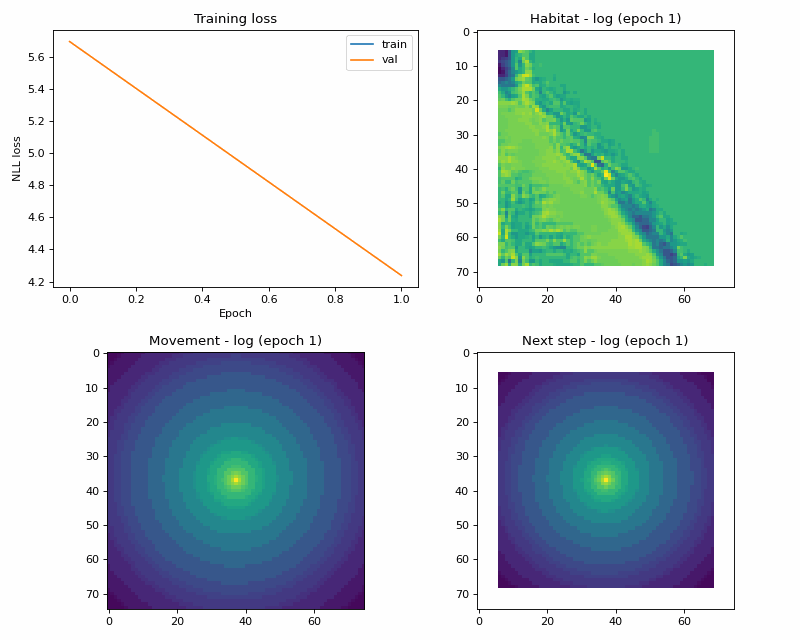

```python
gif_path = str(OUTPUT_DIR / "training_progress.gif")
deepssf.create_gif(str(SNAPSHOT_DIR), gif_path, fps=5)
print(f"Training GIF → {gif_path}")

# Embed the GIF's bytes in an <img> tag so it renders wherever the notebook is
# opened.  Image() would do the same, but its image/gif output is one Quarto
# doesn't render (it falls back to the text repr); HTML is passed through as-is.
gif_b64 = base64.b64encode(Path(gif_path).read_bytes()).decode()
HTML(f'<img src="data:…" style="max-width:100%">')
```

## Training - loss across epochs

```python
# Three panels rather than one: the habitat and movement components move on very
# different scales, so sharing an axis would flatten the habitat curve into a
# horizontal line.  x = 0 is the pre-training baseline recorded by fit().
uniform_nll = np.log(WINDOW_SIZE ** 2)
epochs = np.arange(len(history["val_losses"]))
stages = np.asarray(history["stage"])

fig, axes = plt.subplots(1, 3, figsize=(14, 3.6), constrained_layout=True)

panels = [
    ("Combined", history["val_losses"], history["train_losses"]),
    ("Habitat", history["val_habitat_losses"], None),
    ("Movement", history["val_movement_losses"], None),
]

for ax, (title, val, train) in zip(axes, panels):
    if train is not None:
        ax.plot(epochs, train, color="0.6", lw=1.5, label="train")
    ax.plot(epochs, val, color="C0", lw=1.5, label="val")
    if title == "Habitat":
        # A uniform surface over the window scores log(H*W), so this line is the
        # "learned nothing" mark — the whole question for the habitat head is how
        # far below it the curve gets.  Movement sits far below it from the first
        # epoch, and drawing it there would only compress that panel's axis.
        ax.axhline(uniform_nll, color="0.4", ls="--", lw=1,
                   label=f"uniform ({uniform_nll:.2f})")
    # Shade the staged-training blocks so the schedule is readable off the curve.
    for s in np.unique(stages[stages >= 0])[1::2]:
        within = epochs[stages == s]
        ax.axvspan(within.min() - 0.5, within.max() + 0.5, color="0.92", zorder=0)
    ax.set_xlabel("Epoch (0 = untrained baseline)")
    ax.set_ylabel("NLL (nats)")
    ax.set_title(title)
    ax.legend(frameon=False, fontsize=8)
    ax.spines[["top", "right"]].set_visible(False)

fig.suptitle("Training history — combined loss and its two components")
plt.savefig(str(OUTPUT_DIR / "loss_history.png"), dpi=100)
plt.show()
```

[figure not shown]

## Choosing which checkpoint to use

`fit()` leaves the model holding its **final-epoch** weights, not the best ones, so load a checkpoint before testing or simulating.

- `best_model.pt` — the model to use for **simulation**. Both heads from one epoch, so the joint likelihood is the one that was actually measured.
- `best_model_habitat.pt` / `best_model_movement.pt` — each head at its own best epoch, tracked across the whole run.

Mixing them is a deliberate trade: taking the habitat head from a different epoch gives the sharpest habitat surface to *map*, but the two heads then come from different epochs and the joint model’s likelihood is no longer what either checkpoint recorded. Use it for the landscape predictions below, not for simulating trajectories.

```python
# The joint model — what the simulations further down should use
ckpt = deepssf.load_checkpoint(str(OUTPUT_DIR / "best_model.pt"), model)
print(f"best_model.pt         saved on '{ckpt['checkpoint_criterion']}' "
      f"= {ckpt['checkpoint_score']:.6f}")

hab_ckpt = deepssf.load_checkpoint(str(OUTPUT_DIR / "best_model_habitat.pt"))
print(f"best_model_habitat.pt  saved on '{hab_ckpt['checkpoint_criterion']}' "
      f"= {hab_ckpt['checkpoint_score']:.6f}")

# How much habitat was left on the table by the last epoch.  The two numbers
# above are different quantities (a combined loss and a habitat loss) and are
# not comparable directly, so read the gap off the history instead.
hab_hist = np.asarray(history["val_habitat_losses"])
best_epoch = int(np.nanargmin(hab_hist))
print(f"\nhabitat NLL: best {hab_hist[best_epoch]:.4f} at epoch {best_epoch}, "
      f"final {hab_hist[-1]:.4f} — a gap of {hab_hist[-1] - hab_hist[best_epoch]:+.4f} nats")
print(f"(a uniform surface over the window scores {np.log(WINDOW_SIZE ** 2):.4f} - "
      f"a gap of {hab_hist[-1] - np.log(WINDOW_SIZE ** 2):+.4f}.")

# To map the sharpest habitat surface instead, overwrite just that head:
# load_head_weights(str(OUTPUT_DIR / "best_model_habitat.pt"), model, "habitat")
```

```
best_model.pt         saved on 'total' = 4.097797
best_model_habitat.pt  saved on 'habitat' = 8.288557

habitat NLL: best 8.2886 at epoch 80, final 8.2886 — a gap of +0.0000 nats
(a uniform surface over the window scores 8.6350 - a gap of -0.3464.
```